# 6. Subclassing oce objects

Dan Kelley (https://orcid.org/0000-0001-7808-5911)

2020-02-21

**Abstract.** This vignette explains how new classes of objects can be created, using oce objects as a base class. The advantage of this is that the newly-formed objects will automatically have important properties of oce objects, in terms of operators such as `[[` and `[[<-`, functions such as `subset()` and `summary()`, schemes for handling units, etc.

## 0.1 Initializing oce objects

Oce handles a wide variety of data types, creating sub-classes the inherit from the base class that is named `oce`. However, even if a dataset does not fit within these sub-classes, it is still possible to use some of the features of `oce`, such as accessors, plotting, and summaries.

```r
lon <- -60
lat <- -30
t <- seq(as.POSIXct("2017-08-30"), as.POSIXct("2017-09-01"), by="15 min")
tsec <- as.numeric(t)
u <- sin(tsec * 2 * pi / (3600 * 12.4206))
v <- 0.5 * cos(tsec * 2 * pi / (3600 * 12.4206))
```

These may be inserted into an `oce` object as follows. First, create the object.

```r
library(oce)
o <- new("oce")
```

This contains slots without data:

```r
str(o)
```

```
#> Formal class 'oce' [package "oce"] with 3 slots
#>   ..@ metadata     :List of 2
#>   .. ..$ units: list()
#>   .. ..$ flags: list()
#>   ..@ data         : list()
#>   ..@ processingLog:List of 2
#>   .. ..$ time : POSIXct[1:1], format: "2020-02-21 16:35:17"
#>   .. ..$ value: chr "Create oce object"
```

```r
o <- oceSetData(o, "t", t, list(unit=expression(s), scale=""))
o <- oceSetData(o, "u", u, list(unit=expression(m/s), scale=""))
o <- oceSetData(o, "v", v, list(unit=expression(m/s), scale=""))
```

Astute readers will realize that these data are akin to tidal velocities, and so might agree with the author that `lon` and `lat` belong in the `metadata` slot, not the `data` slot.

```r
o <- oceSetMetadata(o, "longitude", lon)
o <- oceSetMetadata(o, "latitude", lat)
```

At this stage, `o` is a full-fledged `oce` object. It may be summarized with

```r
summary(o)
```

```
#> * Data Overview
#>
#>                   Min.       Mean       Max. Dim. NAs OriginalName
#>     t [s]   1504062000 1504148400 1504234800  193   0            -
#>     u [m/s]   -0.99982  -0.027415          1  193   0            -
#>     v [m/s]   -0.49996 -0.0048211    0.49998  193   0            -
#>
#> * Processing Log
#>     - 2020-02-21 16:35:17 UTC: `Create oce object`
#>     - 2020-02-21 16:35:17 UTC: `oceSetData(object = o, name = "t", value = t, unit = list(unit = expression(s),     scale = ""))`
#>     - 2020-02-21 16:35:17 UTC: `oceSetData(object = o, name = "u", value = u, unit = list(unit = expression(m/s),     scale = ""))`
#>     - 2020-02-21 16:35:17 UTC: `oceSetData(object = o, name = "v", value = v, unit = list(unit = expression(m/s),     scale = ""))`
#>     - 2020-02-21 16:35:17 UTC: `oceSetMetadata(object = o, name = "longitude", value = lon)`
#>     - 2020-02-21 16:35:17 UTC: `oceSetMetadata(object = o, name = "latitude", value = lat)`
```

and individual data components may be extracted with the `[[` notation

```r
o[["latitude"]]                        # from metadata
```

```
#> [1] -30
```

```r
head(o[["t"]])                         # from data
```

```
#> [1] "2017-08-30 00:00:00 ADT" "2017-08-30 00:15:00 ADT"
#> [3] "2017-08-30 00:30:00 ADT" "2017-08-30 00:45:00 ADT"
#> [5] "2017-08-30 01:00:00 ADT" "2017-08-30 01:15:00 ADT"
```

```r
head(o[["u"]])
```

```
#> [1] 0.9961884 0.9772306 0.9426639 0.8930403 0.8291526 0.7520211
```

```r
head(o[["v"]])
```

```
#> [1] -0.04361357 -0.10608997 -0.16687184 -0.22498833 -0.27951117 -0.32956949
```

A crude plot can be done with

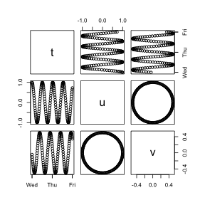

**Figure 11.** Crude plot of constructed `oce` object.

```r
plot(o)
```

Note that the plot uses the `pairs` function to show how all elements of the `data` slot vary with each other. To customize the plot, a new object class should be created, as in the next section.

## 0.2 Creating new oce object classes

Let’s call this new object class `uv`. With this, inventing a new object sub-class is as simple as invoking

```r
setClass("uv", contains="oce")
```

For most objects, it makes sense to define three specialized methods: one to create new objects (called `"initialize"`), one to plot them (`"plot"`), and one to summarize them (`"summary"`).

The initialization can be handled with

```r
setMethod(f="initialize",
          signature="uv",
          definition=function(.Object, time, u, v, longitude, latitude) {
              if (missing(time)) stop("must provide 'time'")
              ## repeat the above also for u, v, longitude, and latitude
              .Object@metadata$units$u <- list(unit=expression(m/s), scale="")
              .Object@metadata$units$v <- list(unit=expression(m/s), scale="")
              .Object@metadata$longitude <- longitude
              .Object@metadata$latitude <- latitude
              .Object@data$time <- time
              .Object@data$u <- u
              .Object@data$v <- v
              .Object@processingLog$time <- presentTime()
              .Object@processingLog$value <- "create 'uv' object"
              return(.Object)
          })
```

This is fairly arcane, but simply copying and pasting this will be enough to get the reader started. Let’s try it:

```r
oo <- new("uv", t, u, v, lon, lat)
```

Next, customize `summary` for this new class:

```r
setMethod(f="summary",
          signature="uv",
          definition=function(object, ...) {
              cat("uv Summary\n-----------\n\n", ...)
              cat(paste("* Location:           ",
                        sprintf("%.5f N", object@metadata$latitude), ", ",
                        sprintf("%.5f E", object@metadata$longitude), "\n", sep=''))
              callNextMethod()
          })
```

The `callNextMethod` will summarize the entries in the `data` slot adequately for this case. Let’s try it:

```r
summary(oo)
```

```
#> uv Summary
#> -----------
#>
#> * Location:           -30.00000 N, -60.00000 E
#> * Time ranges from 2017-08-30 to 2017-09-01 with 193 samples and mean increment 15 min
#> * Data Overview
#>
#>                 Min.       Mean    Max. Dim. NAs OriginalName
#>     u [m/s] -0.99982  -0.027415       1  193   0            -
#>     v [m/s] -0.49996 -0.0048211 0.49998  193   0            -
#>
#> * Processing Log
#>     - 2020-02-21 16:35:18 UTC: `create 'uv' object`
#> NULL
```

Finally, let’s make a custom method for `plot`. This is usually the most complicated part of handling any new object class, because there are usually many ways to look at data. (Some `oce` objects have over a dozen specialized plot styles.) Let’s suppose there are only two desired plot styles: one showing timeseries of `u` and `v` in a two panel plot, and the other showing how `u` and `v` covary.

```r
setMethod(f="plot",
          signature=signature("uv"),
          definition=function(x, which=1, ...)
          {
              if (which == 1) {
                  oce.plot.ts(x[["time"]], x[["u"]], ylab="u [m/s]", ...)
              } else if (which == 2) {
                  oce.plot.ts(x[["time"]], x[["v"]], ylab="v [m/s]", ...)
              } else if (which == 3) {
                  plot(x[["u"]], x[["v"]], xlab="u [m/s]", ylab="v [m/s]", ...)
              }
          })
```

An now, we can try it out

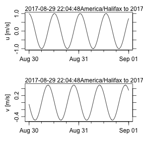

```r
par(mfrow=c(2,1))
plot(oo, which=1)
plot(oo, which=2)
```

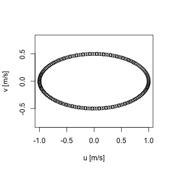

**Figure 13.** Hodograph plot of newly-constructed `uv` object.

```r
plot(oo, which=3, asp=1)
```

# 1 Tutorial

## 1.1 Defining a class

The `setClass` function is the key to defining a new class. Entering `?setClass` in an R console reveals the details of this function, including some notes on how it has evolved since R version 3.0.

We need only a simple form here, with

```r
library(oce)
wave <- setClass(Class="wave", contains="oce")
```

being enough to create a new class called `wave` that inherits the base features of the `oce` class.

To create a new object that inherits from the `wave` class, use e.g.

```r
w <- new("wave")
```

## 1.2 Examining an object

We can see that `w` inherits from the `oce` class with

```r
class(w)
```

```
#> [1] "wave"
#> attr(,"package")
#> [1] ".GlobalEnv"
```

and a check that is common to see in code is

```r
inherits(w, "wave")
```

```
#> [1] TRUE
```

The contents of the object are revealed with

```r
str(w)
```

```
#> Formal class 'wave' [package ".GlobalEnv"] with 3 slots
#>   ..@ metadata     :List of 2
#>   .. ..$ units: list()
#>   .. ..$ flags: list()
#>   ..@ data         : list()
#>   ..@ processingLog:List of 2
#>   .. ..$ time : POSIXct[1:1], format: "2020-02-21 16:35:18"
#>   .. ..$ value: chr "Create oce object"
```

Notice that `w` three `oce` “slots”, named `metadata`, `data` and `processingLog`. These are inherited from `oce`. The first is meant to hold information about the data, such as a file-name, an instrument number, a location of sampling, etc. The second is meant to hold actual data or measurements. And the third, not normally accessed by the user directly, holds information about the object’s evolution (note that the object considers itself an `oce` object). The names of these three slots are usually enough to keep them straight in the analyst’s head, although it can sometimes be difficult deciding whether something belongs in `metadata` or `data`.

The `oce` system also provides its objects with certain operators and functions. For example, `[[` can be used to retrieve the slots, items within the slots, and (in some cases) values that may be calculated from the contents of the slots (e.g. `ctd` and similar objects related to hydrography can return calculated potential temperature or Conservative Temperature, even though neither is typically stored in such datasets).

That’s not the only thing. All `oce` objects give special powers to the `[[` operator, e.g. we can retrieve the `metadata` slot with

```r
w[["metadata"]]
```

```
#> $units
#> list()
#>
#> $flags
#> list()
```

and the same for the data slot

```r
w[["data"]]
```

```
#> list()
```

## 1.3 Adding data to objects

The `[[<-` operator can be used to fill the slots with information, e.g. we could insert a station location of `"STN01"` with

```r
w[["metadata"]]$station <- "STN01"
```

and verify that this worked with

```r
str(w)
```

```
#> Formal class 'wave' [package ".GlobalEnv"] with 3 slots
#>   ..@ metadata     :List of 3
#>   .. ..$ units  : list()
#>   .. ..$ flags  : list()
#>   .. ..$ station: chr "STN01"
#>   ..@ data         : list()
#>   ..@ processingLog:List of 2
#>   .. ..$ time : POSIXct[1:1], format: "2020-02-21 16:35:18"
#>   .. ..$ value: chr "Create oce object"
```

However, there is a better way to insert metadata, with the `oceSetMetadata` function, e.g.

```r
w <- oceSetMetadata(w, "serialNumber", 1234)
```

sets the serial number to 1234, and

```r
str(w[["metadata"]])
```

```
#> List of 4
#>  $ units       : list()
#>  $ flags       : list()
#>  $ station     : chr "STN01"
#>  $ serialNumber: num 1234
```

verifies that this worked.

```r
t <- as.POSIXct("2019-01-01 00:00:00", tz="UTC") + seq(0, 30, length.out=100)
tau <- 10
e <- sin(as.numeric(2 * pi * as.numeric(t) / tau)) + rnorm(t, sd=0.01)
```

(Notice that we are not using the R `ts` form to make this time-series. This is because oceanographic data are commonly acquired on an irregular time interval, so it makes sense to store observation time explicitly, instead of using the start/step/stop approach of the `ts` scheme.)

These data may be inserted into our object with

```r
w <- oceSetData(w, "time", t)
w <- oceSetData(w, "elevation", e)
```

At this point the reader is likely to use `str` to see if this worked, but since the object is starting to fill up, it might make sense to use the `summary` function, which is inherited from `oce`.

```r
summary(w)
```

```
#> * Time ranges from 2019-01-01 to 2019-01-01 00:00:30 with 100 samples and mean increment 0.3030303 s
#> * Data Overview
#>
#>                  Min.      Mean  Max. Dim. NAs OriginalName
#>     elevation -1.0085 0.0024636 1.017  100   0            -
#>
#> * Processing Log
#>     - 2020-02-21 16:35:18 UTC: `Create oce object`
#>     - 2020-02-21 16:35:18 UTC: `oceSetMetadata(object = w, name = "serialNumber", value = 1234)`
#>     - 2020-02-21 16:35:18 UTC: `oceSetData(object = w, name = "time", value = t)`
#>     - 2020-02-21 16:35:18 UTC: `oceSetData(object = w, name = "elevation", value = e)`
```

This produces a useful summary not just of the data, but also of how the object was constructed. But we can do better. In some crazy world, someone might consider measuring elevation in feet, not metres, and so we ought to specify the unit. The way to do this is with the `unit` argument of `oceSetData`. This is a somewhat tricky argument, as a study of the result of `?oceSetData` will reveal. For now, we just show a common way, without explanation, writing

```r
w <- oceSetData(w, "elevation", e, unit=list(unit=expression(m),scale=""))
```

This over-rides the existing definition. Now, let’s look at the summary:

```r
summary(w)
```

```
#> * Time ranges from 2019-01-01 to 2019-01-01 00:00:30 with 100 samples and mean increment 0.3030303 s
#> * Data Overview
#>
#>                      Min.      Mean  Max. Dim. NAs OriginalName
#>     elevation [m] -1.0085 0.0024636 1.017  100   0            -
#>
#> * Processing Log
#>     - 2020-02-21 16:35:18 UTC: `Create oce object`
#>     - 2020-02-21 16:35:18 UTC: `oceSetMetadata(object = w, name = "serialNumber", value = 1234)`
#>     - 2020-02-21 16:35:18 UTC: `oceSetData(object = w, name = "time", value = t)`
#>     - 2020-02-21 16:35:18 UTC: `oceSetData(object = w, name = "elevation", value = e)`
#>     - 2020-02-21 16:35:18 UTC: `oceSetData(object = w, name = "elevation", value = e, unit = list(unit = expression(m),     scale = ""))`
```

Notice that we now have a unit on the elevation, but we have an indication that the value of that quantity was defined twice. This processing-log feature is one of the big advantages of using `oceSetData` over direct insertion into an object.

## 1.4 Adding specialized functions

The most common function to add is a plot function. Since `plot` is a built-in function, we are subclassing it. The details of doing this are provided by `?setMethod`. Again, studying the documentation for that function would be worthwhile, but the gist is provided by a simple example, e.g.

```r
setMethod(f="plot",
    signature=signature("wave"),
    definition=function(x, which=1, ...) {
        if (which == 1) {
            plot(x[["time"]], x[["elevation"]], ...)
        } else if (which == 2) {
            hist(x[["elevation"]], ...)
        } else {
            stop("which must be 1 or 2")
        }
    })
```

Here, the `signature` argument tells R that `plot()` called with a `wave` object as its first argument ought to use the indicated function. That function takes just two arguments: the object to be plotted, and `which`, an indication of the desired plot type.

For example, since `which` defaults to 1, we can get a popular plot with

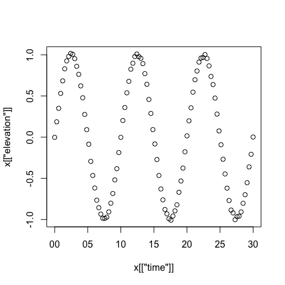

```r
plot(w)
```

Note the simplicity of this action. The user has no reason to state what kind of object this is, because R detects the type and dispatches to the specialized `wave`-plotting function. This may seem like a small thing in the present context, but imagine an analyst writing code to analyse a wide variety of data types: it is very convenient to have a simple function call that works for each.

Since the `...` argument is passed into both the plotting methods. Thus, for example, a cleaner time-series plot might be created with

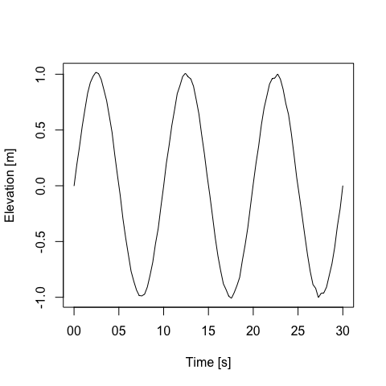

```r
plot(w, type="l", xlab="Time [s]", ylab="Elevation [m]")
```

# 2 Advanced methods

## 2.1 Initializing objects with data

The following lets the user specify `time` and `elevation` when the object is created. It also permits a specification of units, with a default being to us metres.

```r
setMethod(f="initialize",
    signature="wave",
    definition=function(.Object, time, elevation, units) {
        if (missing(units)) {
            .Object@metadata$units <- list()
            if (missing(units))
                .Object@metadata$units$elevation <- list(unit=expression(m), scale="")
        }
        .Object@data$time <- if (missing(time)) NULL else time
        .Object@data$elevation <- if (missing(elevation)) NULL else elevation
        .Object@processingLog$time <- presentTime()
        .Object@processingLog$value <- "create 'wave' object"
        return(.Object)
    }
)
```

A test proves that this works as hoped for.

```r
ww <- new("wave", time=t, elevation=e)
summary(ww)
```

```
#> * Time ranges from 2019-01-01 to 2019-01-01 00:00:30 with 100 samples and mean increment 0.3030303 s
#> * Data Overview
#>
#>                      Min.      Mean  Max. Dim. NAs OriginalName
#>     elevation [m] -1.0085 0.0024636 1.017  100   0            -
#>
#> * Processing Log
#>     - 2020-02-21 16:35:18 UTC: `create 'wave' object`
```

Notice that the units now appear, without complication to the user. Oh, and this object now knows that it is a `wave` object, not an `oce` object our little class is getting smarter by the minute!

## 2.2 Specializing the `[[` operator

As in the previous section, the key of specializing how `[[` works is to use `setMethod()`, but this time the function is named `"[["`. Suppose we want to permit e.g. `w[["peak"]]` as a way to find the maximum value of wave height. This becomes a call to the `"[["` function, with first argument as `w`, and second argument as `"peak"`. We can handle this with:

```r
setMethod(f="[[",
    signature(x="wave", i="ANY", j="ANY"),
    definition=function(x, i, j, ...) {
        if (i == "peak") {
           return(max(x[["elevation"]], na.rm=TRUE))
        } else {
           callNextMethod()
        }
    }
)
```

(The details of the `signature` definition are explained in the documentation provided by `?setMethod`, and readers ought to study that material before changing the `signature` definition.)

The important thing to focus on is the `if` block in the function definition. Called as e.g. `w[["peak"]]` causes `i` to equal `"peak"`, and so the return value will be the maximum elevation. However, in all other instances, the return values is provided by `callNextMethod()`, and what that does is to dig one level deeper for a way to handle `[[`. At that deeper level, it finds the `oce` definition, the details of which can be found with `?"[[,oce-method"`.

The test

```r
w[["peak"]]
```

```
#> [1] 1.017023
```

```r
str(w[["elevation"]])
```

```
#>  num [1:100] -0.00242 0.18643 0.35 0.53135 0.68335 ...
```

verifies that our new code works for getting the peak value, and that it falls back to the `oce` code for other calls.